# FigureYa204PCAscore

Xiaofan Lu

2025-5-20

# 需求描述

想众筹下这个文章的建模方法，不同于常规的lasso, cox回归系数与基因表达量的乘积，这篇文章采用Boruta降维，联合主成分分析第一主成分构建 signature score，特别适合做分子分型分析。

# Requirement Description

I want to crowdfund the modeling method of this article, which is different from the conventional lasso, the product of the cox regression coefficient and the gene expression, this article uses Boruta to reduce the dimension and combine the principal component analysis with the first principal component to construct a signature score, which is especially suitable for molecular typing analysis.

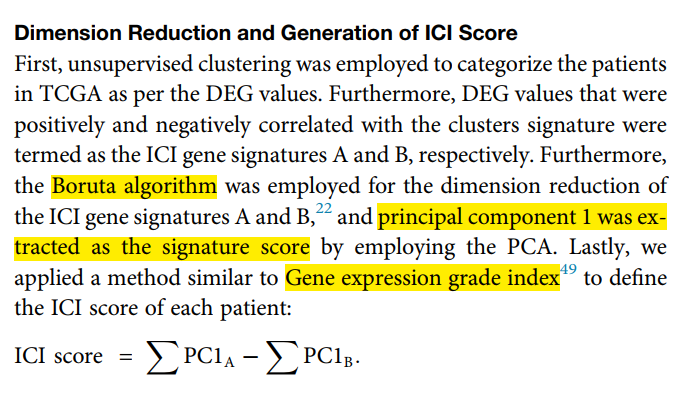

出自https://www.cell.com/molecular-therapy-family/nucleic-acids/fulltext/S2162-2531(20)30259-6 fromhttps://www.cell.com/molecular-therapy-family/nucleic-acids/fulltext/S2162-2531(20)30259-6

# 应用场景

根据Figure201ClusterCorrelation得到的亚型以及ICI signature结果，进一步利用Boruta算法对AB签名降维，并利用PCA计算单样本ICI得分。

# Application Scenarios

According to the isoforms obtained by Figure201ClusterCorrelation and the ICI signature results, the Boruta algorithm was used to reduce the dimensionality of AB signatures, and the single-sample ICI score was calculated by PCA.

# 环境设置

使用国内镜像安装包

# Environment settings

Use the domestic mirror installation package

```r
options("repos"= c(CRAN="https://mirrors.tuna.tsinghua.edu.cn/CRAN/"))
options(BioC_mirror="http://mirrors.tuna.tsinghua.edu.cn/bioconductor/")
install.packages('Boruta')
```

加载包 load package

```r
library(Boruta)
```

```r
library(ggplot2)
library(ggpubr)
library(pheatmap)
Sys.setenv(LANGUAGE = "en") #显示英文报错信息 # Display English error messages
options(stringsAsFactors = FALSE) #禁止chr转成factor # Prohibit converting chr to factor
```

# 输入文件

easy_input_expr.txt，表达矩阵，这里与原文保持一致，用了TPM，也可以用FPKM。FigureYa201ClusterCorrelation的输入文件是FPKM，同样也可以用TPM。

easy_input_cluster.txt，把Figure201ClusterCorrelation获得的亚型信息（ConsensusCluster文件夹里，ConsensusCluster.k=X.consensusClass.csv对应每种分类数量下sample所在的cluster）写在cluster列。其余为样本信息，跟FigureYa201ClusterCorrelation的`easy_input_sinfo.txt`文件一致。

ouput_ICIsignatureGene.txt，Figure201ClusterCorrelation的ICI signature gene结果。

# Input Files

easy_input_expr.txt, the expression matrix, which is consistent with the original text, uses TPM, and FPKM can also be used. The input file of FigureYa201ClusterCorrelation is FPKM, and TPM can also be used.

easy_input_cluster.txt, write the subtype information obtained by Figure201ClusterCorrelation (in the ConsensusCluster folder, ConsensusCluster.k=X.consensusClass.csv the cluster corresponding to the number of samples under each category) in the cluster column. The rest is sample information, which is the same as the ‘easy_input_sinfo.txt’ file of FigureYa201ClusterCorrelation.

ouput_ICIsignatureGene.txt, ICI signature gene results of Figure201ClusterCorrelation.

```r
# 加载表达谱 # Load the expression spectrum
expr <- read.table("easy_input_expr.txt",sep = "\t",row.names = 1,check.names = F,stringsAsFactors = F,header = T)
tumsam <- colnames(expr)[substr(colnames(expr),11,12) == "01"]
expr <- expr[,tumsam]
indata <- t(scale(t(log2(expr + 1)))) # z-score表达谱 # z-score expression spectrum

# 加载亚型结果 # Load subtype results
annCol <- read.table("easy_input_cluster.txt",sep = "\t",row.names = 1,check.names = F,stringsAsFactors = F,header = T)
table(annCol$`Gene cluster`)
```

```
##
##   A   B   C
## 173 166 141
```

```r
# 加载Figure201ClusterCorrelation的ICI signature gene结果
# Load the ICI signature gene result of Figure201ClusterCorrelation
outTab <- read.table("ouput_ICIsignatureGene.txt",sep = "\t",row.names = NULL,header = T,stringsAsFactors = F,check.names = F)
table(outTab$direct) # AB两种签名按相关性正负来分类，正相关标为A，否则标为B # The two types of signatures are classified according to the positive and negative correlations, and the positive correlation is marked as A, otherwise it is marked as B
```

```
##
##   A   B
## 938 131
```

# 用Boruta对ICI signature降维

这一步原则上是应该把AB两种签名一起来构建预后签名的。但这套数据情况特殊，因此遇到了问题（负相关结果被淹没），因此我们拆开A、B签名，分开降维。

## 原则上：一起构建预后签名

# Use Boruta to reduce the dimensionality of the ICI signature

In principle, this step should combine the two signatures of AB to construct the prognostic signature. However, this set of data is a special case, so we have encountered a problem (the negative correlation results are drowned out), so we take apart the A and B signatures and reduce the dimensionality separately.

## In principle: build prognostic signatures together

```r
set.seed(20201024)
dat.boruta <- as.data.frame(t(indata[outTab$gene,rownames(annCol)]))
borutafit <- Boruta(x = as.matrix(dat.boruta),
                    y = as.factor(annCol$`Gene cluster`), # multiclassification
                    doTrace = 2,
                    maxRuns = 100,
                    ntree = 500)
```

```
##  1. run of importance source...
```

```
##  2. run of importance source...
```

```
##  3. run of importance source...
```

```
##  4. run of importance source...
```

```
##  5. run of importance source...
```

```
##  6. run of importance source...
```

```
##  7. run of importance source...
```

```
##  8. run of importance source...
```

```
##  9. run of importance source...
```

```
##  10. run of importance source...
```

```
##  11. run of importance source...
```

```
##  12. run of importance source...
```

```
##  13. run of importance source...
```

```
##  14. run of importance source...
```

```
##  15. run of importance source...
```

```
##  16. run of importance source...
```

```
##  17. run of importance source...
```

```
## After 17 iterations, +12 secs:
```

```
##  confirmed 89 attributes: ABCB4, ACTA1, ACTC1, ACTN2, AKNA and 84 more;
```

```
##  rejected 408 attributes: ABCA12, ABCA3, ABCA9, ACY3, ADH1B and 403 more;
```

```
##  still have 572 attributes left.
```

```
##  18. run of importance source...
```

```
##  19. run of importance source...
```

```
##  20. run of importance source...
```

```
##  21. run of importance source...
```

```
##  22. run of importance source...
```

```
## After 22 iterations, +14 secs:
```

```
##  confirmed 27 attributes: ANKRD44, CCDC170, CD84, CD96, CKM and 22 more;
```

```
##  rejected 81 attributes: ABCB1, ACKR1, ALDH1A1, BATF, CAMK4 and 76 more;
```

```
##  still have 464 attributes left.
```

```
##  23. run of importance source...
```

```
##  24. run of importance source...
```

```
##  25. run of importance source...
```

```
##  26. run of importance source...
```

```
## After 26 iterations, +16 secs:
```

```
##  confirmed 20 attributes: ACACB, ATP8A1, CCR1, CYTIP, ENPP2 and 15 more;
```

```
##  rejected 41 attributes: ABCA8, APOE, APOL3, APOL6, BHLHE22 and 36 more;
```

```
##  still have 403 attributes left.
```

```
##  27. run of importance source...
```

```
##  28. run of importance source...
```

```
##  29. run of importance source...
```

```
## After 29 iterations, +18 secs:
```

```
##  confirmed 11 attributes: ANK2, CD28, CDO1, DOK3, PDCD1 and 6 more;
```

```
##  rejected 21 attributes: AIM2, AOX1, CD79B, COLEC12, CP and 16 more;
```

```
##  still have 371 attributes left.
```

```
##  30. run of importance source...
```

```
##  31. run of importance source...
```

```
##  32. run of importance source...
```

```
##  33. run of importance source...
```

```
## After 33 iterations, +19 secs:
```

```
##  confirmed 7 attributes: ARHGAP4, FYN, JAM2, LILRB2, PYGM and 2 more;
```

```
##  rejected 14 attributes: ALOX5AP, CCDC69, FCRL5, GZMA, IL32 and 9 more;
```

```
##  still have 350 attributes left.
```

```
##  34. run of importance source...
```

```
##  35. run of importance source...
```

```
##  36. run of importance source...
```

```
## After 36 iterations, +21 secs:
```

```
##  confirmed 2 attributes: CHRNA1, SAMSN1;
```

```
##  rejected 19 attributes: APOBEC3D, ATP2A3, CCR7, CD300C, CD52 and 14 more;
```

```
##  still have 329 attributes left.
```

```
##  37. run of importance source...
```

```
##  38. run of importance source...
```

```
##  39. run of importance source...
```

```
## After 39 iterations, +22 secs:
```

```
##  confirmed 2 attributes: CCRL2, MNDA;
```

```
##  rejected 15 attributes: ADRA2A, BTN3A2, BTNL9, CAPN6, CD33 and 10 more;
```

```
##  still have 312 attributes left.
```

```
##  40. run of importance source...
```

```
##  41. run of importance source...
```

```
##  42. run of importance source...
```

```
## After 42 iterations, +23 secs:
```

```
##  confirmed 7 attributes: ABI3, ABI3BP, CILP, GAB3, MB and 2 more;
```

```
##  rejected 9 attributes: ARHGAP25, CD200, CD8B, CLNK, GJB2 and 4 more;
```

```
##  still have 296 attributes left.
```

```
##  43. run of importance source...
```

```
##  44. run of importance source...
```

```
##  45. run of importance source...
```

```
## After 45 iterations, +24 secs:
```

```
##  confirmed 7 attributes: CD3G, FBLN5, ITM2A, PDE4B, RAB33A and 2 more;
```

```
##  rejected 4 attributes: BCL2A1, CD86, PRG4, TNFRSF9;
```

```
##  still have 285 attributes left.
```

```
##  46. run of importance source...
```

```
##  47. run of importance source...
```

```
##  48. run of importance source...
```

```
## After 48 iterations, +25 secs:
```

```
##  confirmed 5 attributes: CD2, CNRIP1, LAT2, SRGN, STAT5A;
```

```
##  rejected 5 attributes: IPCEF1, IQGAP2, KIR2DL4, MERTK, TRANK1;
```

```
##  still have 275 attributes left.
```

```
##  49. run of importance source...
```

```
##  50. run of importance source...
```

```
##  51. run of importance source...
```

```
## After 51 iterations, +27 secs:
```

```
##  confirmed 3 attributes: MAP4K1, RSPO3, TNNC1;
```

```
##  rejected 11 attributes: CD200R1, CMTM7, FAM49A, HHEX, HLA.DMB and 6 more;
```

```
##  still have 261 attributes left.
```

```
##  52. run of importance source...
```

```
##  53. run of importance source...
```

```
##  54. run of importance source...
```

```
## After 54 iterations, +28 secs:
```

```
##  confirmed 3 attributes: CYBB, RHOH, ST8SIA4;
```

```
##  rejected 4 attributes: LILRA2, LYZ, PDGFRL, SFMBT2;
```

```
##  still have 254 attributes left.
```

```
##  55. run of importance source...
```

```
##  56. run of importance source...
```

```
##  57. run of importance source...
```

```
## After 57 iterations, +29 secs:
```

```
##  confirmed 3 attributes: DCLK1, ENTPD1, MYL2;
```

```
##  rejected 3 attributes: CD300LF, CD69, GABRP;
```

```
##  still have 248 attributes left.
```

```
##  58. run of importance source...
```

```
##  59. run of importance source...
```

```
##  60. run of importance source...
```

```
## After 60 iterations, +30 secs:
```

```
##  confirmed 2 attributes: CLEC2D, RASAL3;
```

```
##  rejected 2 attributes: CPED1, SIGLEC10;
```

```
##  still have 244 attributes left.
```

```
##  61. run of importance source...
```

```
##  62. run of importance source...
```

```
## After 62 iterations, +31 secs:
```

```
##  confirmed 3 attributes: ADAMDEC1, DDIT4L, TNFRSF14;
```

```
##  rejected 1 attribute: TLR1;
```

```
##  still have 240 attributes left.
```

```
##  63. run of importance source...
```

```
##  64. run of importance source...
```

```
##  65. run of importance source...
```

```
## After 65 iterations, +32 secs:
```

```
##  confirmed 4 attributes: IL18BP, LPXN, MS4A6A, TESC;
```

```
##  rejected 4 attributes: CXCR4, CYFIP2, FOLR2, SELP;
```

```
##  still have 232 attributes left.
```

```
##  66. run of importance source...
```

```
##  67. run of importance source...
```

```
##  68. run of importance source...
```

```
## After 68 iterations, +33 secs:
```

```
##  confirmed 2 attributes: LST1, TBXAS1;
```

```
##  rejected 1 attribute: CD1D;
```

```
##  still have 229 attributes left.
```

```
##  69. run of importance source...
```

```
##  70. run of importance source...
```

```
##  71. run of importance source...
```

```
## After 71 iterations, +34 secs:
```

```
##  confirmed 1 attribute: CSRP3;
```

```
##  rejected 3 attributes: C7, LRMP, PODN;
```

```
##  still have 225 attributes left.
```

```
##  72. run of importance source...
```

```
##  73. run of importance source...
```

```
## After 73 iterations, +35 secs:
```

```
##  confirmed 1 attribute: FXYD6;
```

```
##  still have 224 attributes left.
```

```
##  74. run of importance source...
```

```
##  75. run of importance source...
```

```
##  76. run of importance source...
```

```
## After 76 iterations, +36 secs:
```

```
##  confirmed 1 attribute: CXCL12;
```

```
##  rejected 1 attribute: DOCK10;
```

```
##  still have 222 attributes left.
```

```
##  77. run of importance source...
```

```
##  78. run of importance source...
```

```
##  79. run of importance source...
```

```
## After 79 iterations, +38 secs:
```

```
##  confirmed 1 attribute: COLQ;
```

```
##  still have 221 attributes left.
```

```
##  80. run of importance source...
```

```
##  81. run of importance source...
```

```
## After 81 iterations, +38 secs:
```

```
##  confirmed 5 attributes: ELMO1, FGF7, GZMM, LY86, SPN;
```

```
##  still have 216 attributes left.
```

```
##  82. run of importance source...
```

```
##  83. run of importance source...
```

```
##  84. run of importance source...
```

```
## After 84 iterations, +40 secs:
```

```
##  confirmed 3 attributes: FPR3, GNG2, MAN1C1;
```

```
##  rejected 4 attributes: ABCA6, F13A1, FGD3, PDK4;
```

```
##  still have 209 attributes left.
```

```
##  85. run of importance source...
```

```
##  86. run of importance source...
```

```
##  87. run of importance source...
```

```
## After 87 iterations, +41 secs:
```

```
##  confirmed 1 attribute: NCF4;
```

```
##  rejected 1 attribute: FLT3;
```

```
##  still have 207 attributes left.
```

```
##  88. run of importance source...
```

```
##  89. run of importance source...
```

```
## After 89 iterations, +41 secs:
```

```
##  confirmed 2 attributes: FDCSP, ITK;
```

```
##  rejected 3 attributes: IRF4, P2RX5, SIRPG;
```

```
##  still have 202 attributes left.
```

```
##  90. run of importance source...
```

```
##  91. run of importance source...
```

```
##  92. run of importance source...
```

```
## After 92 iterations, +43 secs:
```

```
##  confirmed 1 attribute: BCL2L14;
```

```
##  rejected 2 attributes: FCRL2, LY9;
```

```
##  still have 199 attributes left.
```

```
##  93. run of importance source...
```

```
##  94. run of importance source...
```

```
## After 94 iterations, +43 secs:
```

```
##  confirmed 1 attribute: CASQ1;
```

```
##  still have 198 attributes left.
```

```
##  95. run of importance source...
```

```
##  96. run of importance source...
```

```
##  97. run of importance source...
```

```
##  98. run of importance source...
```

```
##  99. run of importance source...
```

```
## After 99 iterations, +45 secs:
```

```
##  confirmed 1 attribute: YPEL1;
```

```
##  still have 197 attributes left.
```

```r
boruta_fea <- attStats(borutafit)
boruta_fea <- rownames(boruta_fea[which(boruta_fea$decision == "Confirmed"),])
boruta.all <- outTab[which(outTab$gene %in% boruta_fea),]
table(boruta.all$direct)
```

```
##
##   A
## 215
```

```r
# 拆分降维后的AB签名
# Split the AB signature after dimensionality reduction

#boruta.A <- boruta.all[boruta.all$direct == "A",]
#boruta.B <- boruta.all[boruta.all$direct == "B",]
```

这里结果全部为A签名，分析原因：

从Figure201ClusterCorrelation的相关性分析可知，正相关占主导地位，所以在上一步的回归分析里，可想而知负相关结果会被淹没。

怎么办呢？

原文没有提及具体做法。这里我拆开A、B签名，分开降维，以保证负相关基因个数不会太少。

Here, all results correspond to Signature A. Analysis of the reasons:

From the correlation analysis in FigureYa201ClusterCorrelation, it is evident that positive correlations dominate. Consequently, in the preceding regression analysis, negative correlation results were likely overshadowed.

How to address this?

The original paper does not specify a detailed approach. To ensure an adequate representation of negatively correlated genes, I separated Signatures A and B and performed dimensionality reduction independently. This prevents the negative correlation gene set from being too sparse.

## 灵活处理：拆开A、B签名，分开降维

## Flexible processing: Disassemble A and B signatures and reduce dimensionality separately

```r
# 提取A签名
# Extract A signature
set.seed(20201024)
dat.boruta <- as.data.frame(t(indata[outTab[which(outTab$direct == "A"),"gene"],rownames(annCol)]))
borutafit <- Boruta(x = as.matrix(dat.boruta),
                    y = as.factor(annCol$`Gene cluster`), # multiclassification
                    doTrace = 2,
                    maxRuns = 100,
                    ntree = 500)
```

```
##  1. run of importance source...
```

```
##  2. run of importance source...
```

```
##  3. run of importance source...
```

```
##  4. run of importance source...
```

```
##  5. run of importance source...
```

```
##  6. run of importance source...
```

```
##  7. run of importance source...
```

```
##  8. run of importance source...
```

```
##  9. run of importance source...
```

```
##  10. run of importance source...
```

```
##  11. run of importance source...
```

```
##  12. run of importance source...
```

```
##  13. run of importance source...
```

```
##  14. run of importance source...
```

```
##  15. run of importance source...
```

```
##  16. run of importance source...
```

```
##  17. run of importance source...
```

```
## After 17 iterations, +10 secs:
```

```
##  confirmed 99 attributes: ABCB4, ACTN2, ANGPTL1, ANKRD44, APBB1IP and 94 more;
```

```
##  rejected 306 attributes: ABCA9, ACY3, ADH1B, ADRA2A, AIM2 and 301 more;
```

```
##  still have 533 attributes left.
```

```
##  18. run of importance source...
```

```
##  19. run of importance source...
```

```
##  20. run of importance source...
```

```
##  21. run of importance source...
```

```
## After 21 iterations, +12 secs:
```

```
##  confirmed 17 attributes: ACTA1, ACTC1, ANK2, ATP8A1, CKM and 12 more;
```

```
##  rejected 92 attributes: ABCA3, ACKR1, ADAM28, AFF3, ANXA2R and 87 more;
```

```
##  still have 424 attributes left.
```

```
##  22. run of importance source...
```

```
##  23. run of importance source...
```

```
##  24. run of importance source...
```

```
##  25. run of importance source...
```

```
## After 25 iterations, +14 secs:
```

```
##  confirmed 14 attributes: ABI3, ACACB, CCDC170, CD3E, CHRNA1 and 9 more;
```

```
##  rejected 27 attributes: ALDH1A1, ALPK2, BTN3A2, CCL5, CD163 and 22 more;
```

```
##  still have 383 attributes left.
```

```
##  26. run of importance source...
```

```
##  27. run of importance source...
```

```
##  28. run of importance source...
```

```
##  29. run of importance source...
```

```
## After 29 iterations, +16 secs:
```

```
##  confirmed 15 attributes: CD180, CD28, HAVCR2, HVCN1, JAM2 and 10 more;
```

```
##  rejected 19 attributes: ALOX5AP, CAPN6, CD19, CD7, CIITA and 14 more;
```

```
##  still have 349 attributes left.
```

```
##  30. run of importance source...
```

```
##  31. run of importance source...
```

```
##  32. run of importance source...
```

```
## After 32 iterations, +17 secs:
```

```
##  confirmed 7 attributes: AKNA, CD2, FGR, GAB3, MYL1 and 2 more;
```

```
##  rejected 16 attributes: ABCA8, ABCB1, CHRDL1, CXCL13, DPT and 11 more;
```

```
##  still have 326 attributes left.
```

```
##  33. run of importance source...
```

```
##  34. run of importance source...
```

```
##  35. run of importance source...
```

```
##  36. run of importance source...
```

```
## After 36 iterations, +19 secs:
```

```
##  confirmed 1 attribute: FLI1;
```

```
##  rejected 12 attributes: CD79B, CTSO, DPEP2, LCK, LRMP and 7 more;
```

```
##  still have 313 attributes left.
```

```
##  37. run of importance source...
```

```
##  38. run of importance source...
```

```
##  39. run of importance source...
```

```
## After 39 iterations, +20 secs:
```

```
##  confirmed 7 attributes: CCRL2, CDO1, PIK3R5, RASSF4, SIGLEC9 and 2 more;
```

```
##  rejected 12 attributes: CD86, CXCR4, FLT3, FOLR2, GABRP and 7 more;
```

```
##  still have 294 attributes left.
```

```
##  40. run of importance source...
```

```
##  41. run of importance source...
```

```
##  42. run of importance source...
```

```
## After 42 iterations, +21 secs:
```

```
##  confirmed 4 attributes: DDIT4L, DOK3, NLRC3, RSPO3;
```

```
##  rejected 4 attributes: ENPP6, F13A1, SPOCK2, TNFRSF9;
```

```
##  still have 286 attributes left.
```

```
##  43. run of importance source...
```

```
##  44. run of importance source...
```

```
##  45. run of importance source...
```

```
## After 45 iterations, +22 secs:
```

```
##  confirmed 3 attributes: ITM2A, STAT5A, VCAM1;
```

```
##  rejected 12 attributes: APOBEC3G, CD74, CMTM7, FGD3, HLA.DRA and 7 more;
```

```
##  still have 271 attributes left.
```

```
##  46. run of importance source...
```

```
##  47. run of importance source...
```

```
##  48. run of importance source...
```

```
## After 48 iterations, +24 secs:
```

```
##  confirmed 3 attributes: ABI3BP, GIMAP2, SAMSN1;
```

```
##  rejected 4 attributes: GPR183, IL7R, KIR2DL4, SLAMF8;
```

```
##  still have 264 attributes left.
```

```
##  49. run of importance source...
```

```
##  50. run of importance source...
```

```
##  51. run of importance source...
```

```
## After 51 iterations, +25 secs:
```

```
##  confirmed 1 attribute: LRRC25;
```

```
##  rejected 9 attributes: ATP2A3, BTNL9, CD1D, CD79A, PAQR8 and 4 more;
```

```
##  still have 254 attributes left.
```

```
##  52. run of importance source...
```

```
##  53. run of importance source...
```

```
##  54. run of importance source...
```

```
## After 54 iterations, +27 secs:
```

```
##  confirmed 4 attributes: CYBB, IL18BP, MB, MYL2;
```

```
##  rejected 3 attributes: LCP1, PRF1, SELP;
```

```
##  still have 247 attributes left.
```

```
##  55. run of importance source...
```

```
##  56. run of importance source...
```

```
## After 56 iterations, +28 secs:
```

```
##  confirmed 2 attributes: DCLK1, FXYD6;
```

```
##  rejected 2 attributes: GFI1, IL12RB1;
```

```
##  still have 243 attributes left.
```

```
##  57. run of importance source...
```

```
##  58. run of importance source...
```

```
##  59. run of importance source...
```

```
## After 59 iterations, +30 secs:
```

```
##  confirmed 3 attributes: CD3G, CLEC2D, CNRIP1;
```

```
##  rejected 2 attributes: CD200R1, NFAM1;
```

```
##  still have 238 attributes left.
```

```
##  60. run of importance source...
```

```
##  61. run of importance source...
```

```
##  62. run of importance source...
```

```
## After 62 iterations, +32 secs:
```

```
##  confirmed 2 attributes: FDCSP, PDE4B;
```

```
##  rejected 2 attributes: MS4A4A, SFMBT2;
```

```
##  still have 234 attributes left.
```

```
##  63. run of importance source...
```

```
##  64. run of importance source...
```

```
##  65. run of importance source...
```

```
## After 65 iterations, +34 secs:
```

```
##  confirmed 3 attributes: ENTPD1, RAI2, RASAL3;
```

```
##  rejected 1 attribute: LAG3;
```

```
##  still have 230 attributes left.
```

```
##  66. run of importance source...
```

```
##  67. run of importance source...
```

```
##  68. run of importance source...
```

```
## After 68 iterations, +35 secs:
```

```
##  confirmed 3 attributes: RAB33A, SIGLEC7, TNFRSF14;
```

```
##  rejected 1 attribute: HLA.DMB;
```

```
##  still have 226 attributes left.
```

```
##  69. run of importance source...
```

```
##  70. run of importance source...
```

```
## After 70 iterations, +36 secs:
```

```
##  confirmed 3 attributes: LAT2, LY86, TESC;
```

```
##  rejected 1 attribute: IFIT3;
```

```
##  still have 222 attributes left.
```

```
##  71. run of importance source...
```

```
##  72. run of importance source...
```

```
##  73. run of importance source...
```

```
## After 73 iterations, +37 secs:
```

```
##  confirmed 2 attributes: LST1, TBXAS1;
```

```
##  rejected 3 attributes: COLEC12, FAM49A, LTB;
```

```
##  still have 217 attributes left.
```

```
##  74. run of importance source...
```

```
##  75. run of importance source...
```

```
##  76. run of importance source...
```

```
## After 76 iterations, +38 secs:
```

```
##  confirmed 4 attributes: BCL2L14, FGF7, MAN1C1, NCF4;
```

```
##  still have 213 attributes left.
```

```
##  77. run of importance source...
```

```
##  78. run of importance source...
```

```
## After 78 iterations, +39 secs:
```

```
##  confirmed 4 attributes: CSRP3, FBLN5, RHOH, SRGN;
```

```
##  rejected 1 attribute: LTA;
```

```
##  still have 208 attributes left.
```

```
##  79. run of importance source...
```

```
##  80. run of importance source...
```

```
##  81. run of importance source...
```

```
## After 81 iterations, +40 secs:
```

```
##  rejected 2 attributes: FCRL2, HLA.DOA;
```

```
##  still have 206 attributes left.
```

```
##  82. run of importance source...
```

```
##  83. run of importance source...
```

```
##  84. run of importance source...
```

```
##  85. run of importance source...
```

```
##  86. run of importance source...
```

```
## After 86 iterations, +42 secs:
```

```
##  confirmed 2 attributes: CXCL12, YPEL1;
```

```
##  still have 204 attributes left.
```

```
##  87. run of importance source...
```

```
##  88. run of importance source...
```

```
##  89. run of importance source...
```

```
## After 89 iterations, +44 secs:
```

```
##  rejected 1 attribute: P2RX5;
```

```
##  still have 203 attributes left.
```

```
##  90. run of importance source...
```

```
##  91. run of importance source...
```

```
## After 91 iterations, +44 secs:
```

```
##  confirmed 2 attributes: COLQ, GAPT;
```

```
##  rejected 1 attribute: ICAM3;
```

```
##  still have 200 attributes left.
```

```
##  92. run of importance source...
```

```
##  93. run of importance source...
```

```
##  94. run of importance source...
```

```
## After 94 iterations, +46 secs:
```

```
##  confirmed 1 attribute: ELMO1;
```

```
##  rejected 3 attributes: IL4I1, NR3C2, RASGRP2;
```

```
##  still have 196 attributes left.
```

```
##  95. run of importance source...
```

```
##  96. run of importance source...
```

```
##  97. run of importance source...
```

```
##  98. run of importance source...
```

```
##  99. run of importance source...
```

```
## After 99 iterations, +48 secs:
```

```
##  confirmed 2 attributes: ADAMDEC1, SIDT1;
```

```
##  rejected 1 attribute: MERTK;
```

```
##  still have 193 attributes left.
```

```r
boruta_fea <- attStats(borutafit)
boruta_fea <- rownames(boruta_fea[which(boruta_fea$decision == "Confirmed"),])
boruta.A <- outTab[which(outTab$gene %in% boruta_fea),]
# 降维前后基因数量
# Number of genes before and after dimension reduction
ncol(dat.boruta)
```

```
## [1] 938
```

```r
nrow(boruta.A)
```

```
## [1] 208
```

```r
# 提取B签名
# Extract signature B
set.seed(20201024)
dat.boruta <- as.data.frame(t(indata[outTab[which(outTab$direct == "B"),"gene"],rownames(annCol)]))
borutafit <- Boruta(x = as.matrix(dat.boruta),
                    y = as.factor(annCol$`Gene cluster`), # multiclassification
                    doTrace = 2,
                    maxRuns = 100,
                    ntree = 500)
```

```
##  1. run of importance source...
```

```
##  2. run of importance source...
```

```
##  3. run of importance source...
```

```
##  4. run of importance source...
```

```
##  5. run of importance source...
```

```
##  6. run of importance source...
```

```
##  7. run of importance source...
```

```
##  8. run of importance source...
```

```
##  9. run of importance source...
```

```
##  10. run of importance source...
```

```
##  11. run of importance source...
```

```
##  12. run of importance source...
```

```
##  13. run of importance source...
```

```
##  14. run of importance source...
```

```
## After 14 iterations, +6 secs:
```

```
##  confirmed 12 attributes: ARTN, FAM83C, FGFBP1, GAST, IL1A and 7 more;
```

```
##  rejected 45 attributes: AHNAK2, AKR1C3, CCNA1, CHP2, CLCA2 and 40 more;
```

```
##  still have 74 attributes left.
```

```
##  15. run of importance source...
```

```
##  16. run of importance source...
```

```
##  17. run of importance source...
```

```
##  18. run of importance source...
```

```
## After 18 iterations, +7.6 secs:
```

```
##  confirmed 3 attributes: FOSL1, GJB6, KRT16;
```

```
##  rejected 14 attributes: ATP10B, BCHE, CALB1, FLRT3, GAL and 9 more;
```

```
##  still have 57 attributes left.
```

```
##  19. run of importance source...
```

```
##  20. run of importance source...
```

```
##  21. run of importance source...
```

```
##  22. run of importance source...
```

```
## After 22 iterations, +9 secs:
```

```
##  confirmed 2 attributes: MAL, TFPI2;
```

```
##  rejected 8 attributes: CRNN, CWH43, DSG1, IL1B, NDRG1 and 3 more;
```

```
##  still have 47 attributes left.
```

```
##  23. run of importance source...
```

```
##  24. run of importance source...
```

```
##  25. run of importance source...
```

```
##  26. run of importance source...
```

```
## After 26 iterations, +10 secs:
```

```
##  confirmed 1 attribute: SLC2A1;
```

```
##  rejected 4 attributes: BTBD16, F2RL1, GLI2, TNNI3;
```

```
##  still have 42 attributes left.
```

```
##  27. run of importance source...
```

```
##  28. run of importance source...
```

```
##  29. run of importance source...
```

```
## After 29 iterations, +11 secs:
```

```
##  confirmed 3 attributes: GDPD2, GJB2, SLC16A9;
```

```
##  rejected 2 attributes: IL20RB, SLC7A11;
```

```
##  still have 37 attributes left.
```

```
##  30. run of importance source...
```

```
##  31. run of importance source...
```

```
##  32. run of importance source...
```

```
## After 32 iterations, +12 secs:
```

```
##  rejected 2 attributes: ABCA12, PPP2R2C;
```

```
##  still have 35 attributes left.
```

```
##  33. run of importance source...
```

```
##  34. run of importance source...
```

```
##  35. run of importance source...
```

```
## After 35 iterations, +13 secs:
```

```
##  confirmed 2 attributes: PYGL, RAP1GAP;
```

```
##  still have 33 attributes left.
```

```
##  36. run of importance source...
```

```
##  37. run of importance source...
```

```
##  38. run of importance source...
```

```
## After 38 iterations, +14 secs:
```

```
##  confirmed 1 attribute: HILPDA;
```

```
##  still have 32 attributes left.
```

```
##  39. run of importance source...
```

```
##  40. run of importance source...
```

```
##  41. run of importance source...
```

```
##  42. run of importance source...
```

```
##  43. run of importance source...
```

```
##  44. run of importance source...
```

```
##  45. run of importance source...
```

```
##  46. run of importance source...
```

```
##  47. run of importance source...
```

```
##  48. run of importance source...
```

```
##  49. run of importance source...
```

```
## After 49 iterations, +17 secs:
```

```
##  confirmed 1 attribute: IL24;
```

```
##  still have 31 attributes left.
```

```
##  50. run of importance source...
```

```
##  51. run of importance source...
```

```
##  52. run of importance source...
```

```
## After 52 iterations, +18 secs:
```

```
##  confirmed 1 attribute: LY6D;
```

```
##  rejected 1 attribute: IRX4;
```

```
##  still have 29 attributes left.
```

```
##  53. run of importance source...
```

```
##  54. run of importance source...
```

```
##  55. run of importance source...
```

```
##  56. run of importance source...
```

```
##  57. run of importance source...
```

```
##  58. run of importance source...
```

```
## After 58 iterations, +20 secs:
```

```
##  rejected 1 attribute: ATP2C2;
```

```
##  still have 28 attributes left.
```

```
##  59. run of importance source...
```

```
##  60. run of importance source...
```

```
## After 60 iterations, +20 secs:
```

```
##  confirmed 1 attribute: SH2D5;
```

```
##  rejected 1 attribute: ARC;
```

```
##  still have 26 attributes left.
```

```
##  61. run of importance source...
```

```
##  62. run of importance source...
```

```
##  63. run of importance source...
```

```
## After 63 iterations, +21 secs:
```

```
##  confirmed 1 attribute: KLK9;
```

```
##  rejected 1 attribute: CXCL17;
```

```
##  still have 24 attributes left.
```

```
##  64. run of importance source...
```

```
##  65. run of importance source...
```

```
##  66. run of importance source...
```

```
##  67. run of importance source...
```

```
##  68. run of importance source...
```

```
##  69. run of importance source...
```

```
##  70. run of importance source...
```

```
##  71. run of importance source...
```

```
##  72. run of importance source...
```

```
##  73. run of importance source...
```

```
##  74. run of importance source...
```

```
##  75. run of importance source...
```

```
##  76. run of importance source...
```

```
##  77. run of importance source...
```

```
##  78. run of importance source...
```

```
##  79. run of importance source...
```

```
##  80. run of importance source...
```

```
##  81. run of importance source...
```

```
## After 81 iterations, +26 secs:
```

```
##  rejected 1 attribute: SLAMF9;
```

```
##  still have 23 attributes left.
```

```
##  82. run of importance source...
```

```
##  83. run of importance source...
```

```
##  84. run of importance source...
```

```
##  85. run of importance source...
```

```
##  86. run of importance source...
```

```
## After 86 iterations, +28 secs:
```

```
##  rejected 1 attribute: HMGA2;
```

```
##  still have 22 attributes left.
```

```
##  87. run of importance source...
```

```
##  88. run of importance source...
```

```
##  89. run of importance source...
```

```
##  90. run of importance source...
```

```
##  91. run of importance source...
```

```
##  92. run of importance source...
```

```
##  93. run of importance source...
```

```
##  94. run of importance source...
```

```
##  95. run of importance source...
```

```
##  96. run of importance source...
```

```
##  97. run of importance source...
```

```
##  98. run of importance source...
```

```
##  99. run of importance source...
```

```r
boruta_fea <- attStats(borutafit)
boruta_fea <- rownames(boruta_fea[which(boruta_fea$decision == "Confirmed"),])
boruta.B <- outTab[which(outTab$gene %in% boruta_fea),]
# 降维前后基因数量
# Number of genes before and after dimension reduction
ncol(dat.boruta)
```

```
## [1] 131
```

```r
nrow(boruta.B)
```

```
## [1] 28
```

# 用降维后的签名画热图

# Draw a heatmap with the dimensionally reduced signature

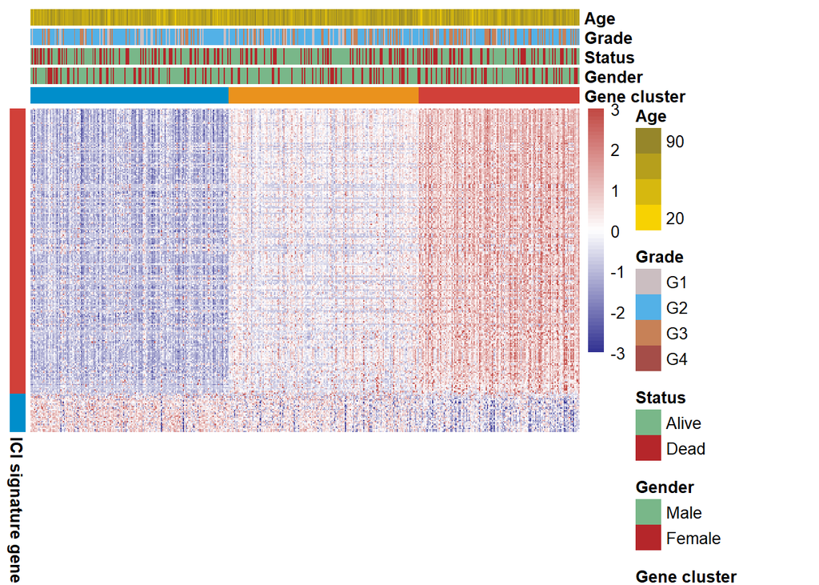

```r
annRow <- data.frame("ICI signature gene" = rep(c("A","B"), c(nrow(boruta.A), nrow(boruta.B))),
                     row.names = c(boruta.A$gene,boruta.B$gene),
                     check.names = F,
                     stringsAsFactors = F)
annColors <- list("Gene cluster" = c("A" = "#008ECB", "B" = "#EA921D", "C" = "#D14039"),
                  "Gender" = c("Male" = "#79B789", "Female" = "#B5262A"),
                  "Status" = c("Alive" = "#79B789", "Dead" = "#B5262A"),
                  "Grade" = c("G1" = "#CBBEC1", "G2" = "#53B1E7", "G3" = "#C78157", "G4" = "#A54D48"),
                  "Age" = colorRampPalette(c("#F7D202", "#96862A"))(64),
                  "ICI signature gene" = c("A" = "#D14039", "B" = "#008ECB"))
plotdata <- indata[rownames(annRow), rownames(annCol)]
plotdata[plotdata > 3] <- 3 # 截断极端值 # Truncate extreme values
plotdata[plotdata < -3] <- -3 # 截断极端值 # Truncate extreme values
pheatmap(plotdata,
         cluster_rows = F,
         cluster_cols = F,
         show_rownames = F,
         show_colnames = F,
         annotation_row = annRow,
         annotation_col = annCol,
         annotation_colors = annColors,
         color = colorRampPalette(c("#343493", "white", "#C24A45"))(64))
```

```r
dev.copy2pdf(file = "heatmap_dimension_reduced.pdf", width = 10, height = 8) # 保存图像 # Save the image
```

把这里的`heatmap_dimension_reduced.pdf`跟FigureYa201ClusterCorrelation的`ClusterCorrelation.pdf`对比一下，看看降维前后的效果。

Compare the ‘heatmap_dimension_reduced.pdf’ here with the ‘ClusterCorrelation.pdf’ of FigureYa201ClusterCorrelation to see the effect before and after dimensionality reduction.

# 联合主成分分析第一主成分计算ICI得分

# Combined principal component analysis (PCA) first principal component to calculate the ICI score

```r
# 在“输入文件”那里，已经做过z-score处理，因此这里不再进行标准化
# In the "Input File" section, the z-score has already been processed, so it is no longer normalized here
expr.A <- indata[boruta.A$gene,rownames(annCol)]
pca.A <- prcomp(t(expr.A), scale = F, center = F) # 如果数据没有标准化，这里都要设置为TRUE # If the data is not normalized, it must be set to TRUE
pca1.A <- pca.A$x[,1] # 取出第一主成分 # Remove the first principal component

expr.B <- indata[boruta.B$gene,rownames(annCol)]
pca.B <- prcomp(t(expr.B), scale = F, center = F) #如果数据没有标准化，这里都要设置为TRUE # If the data is not normalized, it should be set to TRUE
pca1.B <- pca.B$x[,1] # 取出第一主成分 # Remove the first principal component

ICI.score <- pca1.A - pca1.B # 主成份相减得到ICI得分 # Subtract the principal components to get the ICI score
ICI.outtab <- data.frame(samID = rownames(annCol),
                         pca1.A = pca1.A[rownames(annCol)],
                         pca1.B = pca1.B[rownames(annCol)],
                         ICI.score = ICI.score[rownames(annCol)],
                         subtype = annCol$`Gene cluster`,
                         stringsAsFactors = F)
# 输出到文件
# Output to file
write.table(ICI.outtab,"output_ICI_score.txt",sep = "\t",row.names = F,col.names = T,quote = F)
```

# 画图对比ABC三类的ICI score

参考FigureYa162boxViolin的画法

# Draw and compare the ICI scores of the three types of ABC

Refer to FigureYa162boxViolin’s drawing method

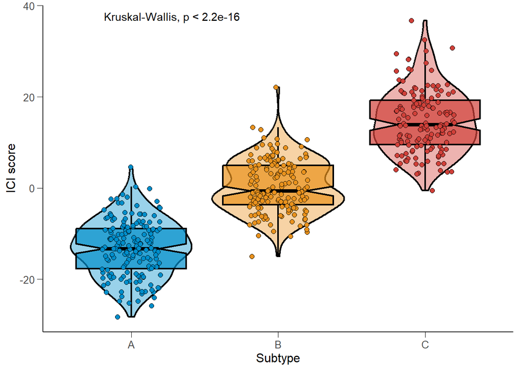

```r
ggplot(data = ICI.outtab,aes(x = subtype, y = ICI.score, fill = subtype))+
  scale_fill_manual(values = c("#008ECB", "#EA921D", "#D14039")) +
  geom_violin(alpha=0.4, position = position_dodge(width = .75),
              size=0.8, color="black") + # 边框线黑色 # The border line is black
  geom_boxplot(notch = TRUE, outlier.size = -1,
               color="black", lwd=0.8, alpha = 0.7)+ # 背景色透明化 # The background color is transparent
  geom_point(shape = 21, size=2,
             position = position_jitterdodge(),
             color="black", alpha=1)+ # 边框线黑色 # The border line is black
  theme_classic() +
  ylab(expression("ICI score")) +
  xlab("Subtype")  +
  theme(axis.ticks = element_line(size=0.2,color="black"),
    axis.ticks.length = unit(0.2,"cm"),
    legend.position = "none",
    axis.title = element_text(size = 12),
    axis.text = element_text(size = 10)) +
  stat_compare_means(method = "kruskal.test", label.y = max(ICI.score))
```

```r
ggsave(filename = "ICI_score.pdf", width = 5, height = 5)
```